# Project 6 UnSupervised Learning

### Lets get Sihouette score for different clusters using Euclidean distance and AVERAGE linkage

```
For n_clusters = 2 The average silhouette_score is : 0.5703183487340514
For n_clusters = 3 The average silhouette_score is : 0.515922432650965
For n_clusters = 4 The average silhouette_score is : 0.47495143595793504
For n_clusters = 5 The average silhouette_score is : 0.44039753024783956
For n_clusters = 6 The average silhouette_score is : 0.4153547954831452
For n_clusters = 7 The average silhouette_score is : 0.41837756746720256
For n_clusters = 8 The average silhouette_score is : 0.34306710358280806
For n_clusters = 9 The average silhouette_score is : 0.34154869328908927
For n_clusters = 10 The average silhouette_score is : 0.34550947121387965
```

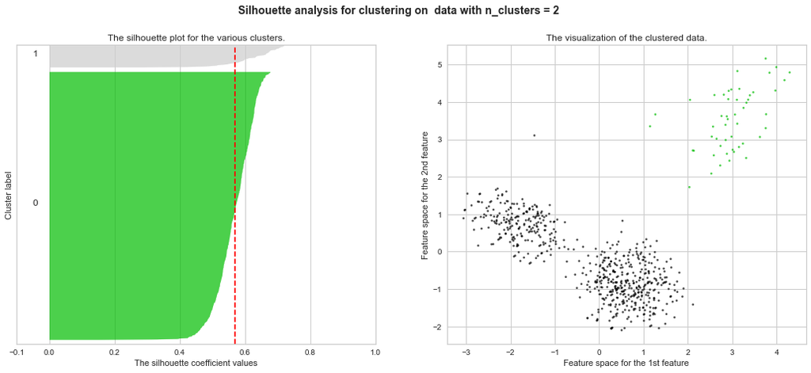

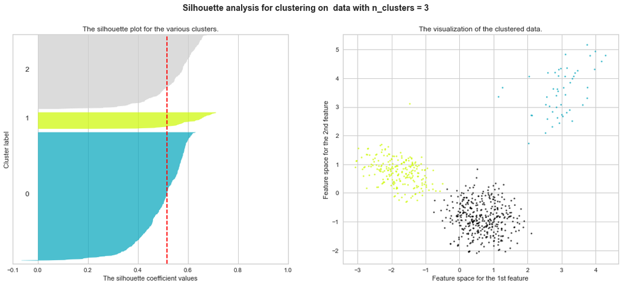

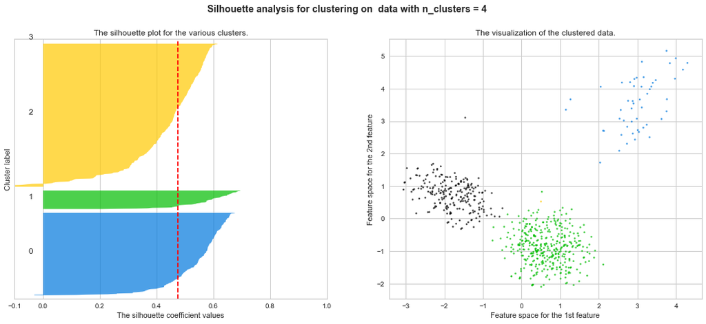

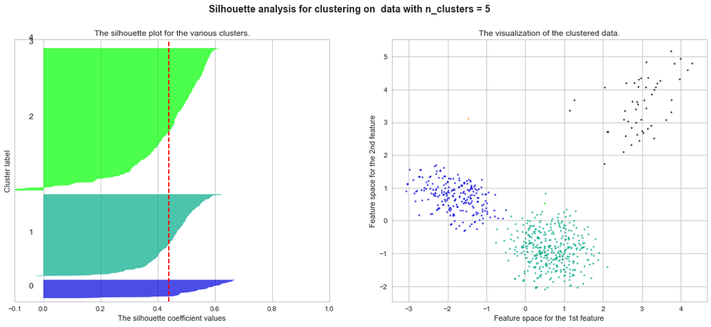

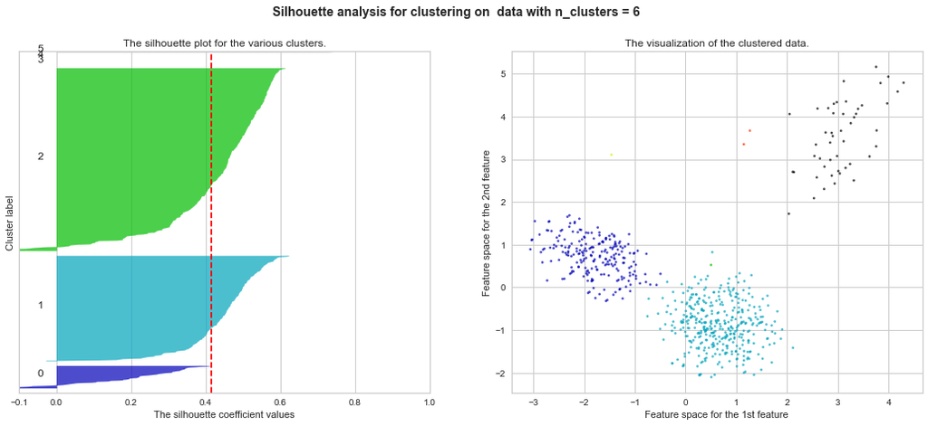

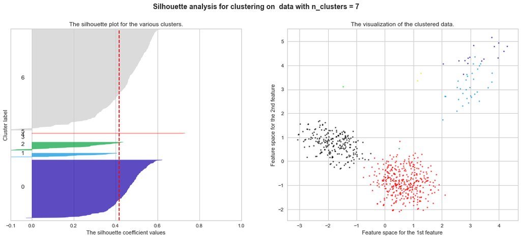

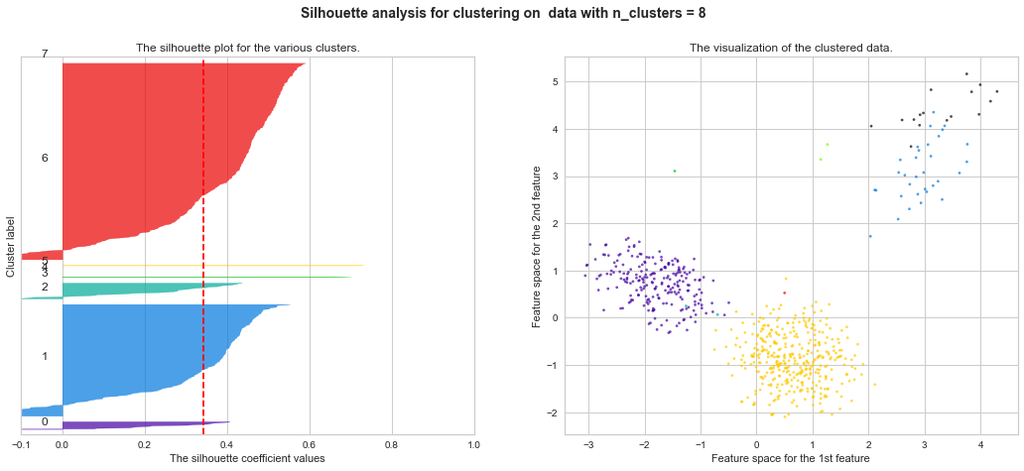

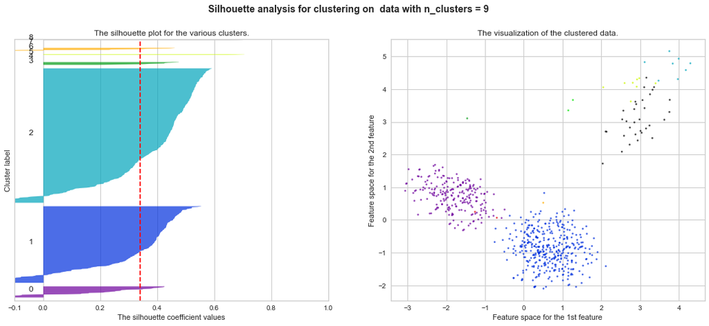

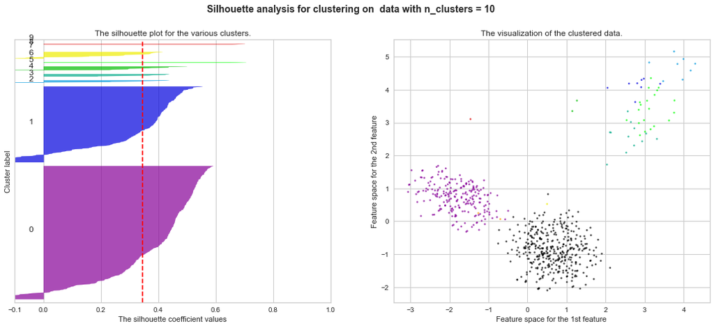

```python
for n_clusters in range(2, 11):
    # Create a subplot with 1 row and 2 columns
    fig, (ax1, ax2) = plt.subplots(1, 2)
    fig.set_size_inches(18, 7)

    # The 1st subplot is the silhouette plot
    # The silhouette coefficient can range from -1, 1 but in this example all
    # lie within [-0.1, 1]
    ax1.set_xlim([-0.1, 1])
    # The (n_clusters+1)*10 is for inserting blank space between silhouette
    # plots of individual clusters, to demarcate them clearly.
    ax1.set_ylim([0, len(X) + (n_clusters) * 10])

    # Initialize the clusterer with n_clusters value and a random generator
    # seed of 10 for reproducibility.

    clusterer = AgglomerativeClustering(
        n_clusters=n_clusters, affinity="euclidean", linkage="average"
    )
    cluster_labels = clusterer.fit_predict(X)

    # The silhouette_score gives the average value for all the samples.
    # This gives a perspective into the density and separation of the formed
    # clusters
    silhouette_avg = silhouette_score(X, cluster_labels)
    print(
        "For n_clusters =",
        n_clusters,
        "The average silhouette_score is :",
        silhouette_avg,
    )

    # Compute the silhouette scores for each sample
    sample_silhouette_values = silhouette_samples(X, cluster_labels)

    y_lower = 10
    for i in range(n_clusters):
        # Aggregate the silhouette scores for samples belonging to
        # cluster i, and sort them
        ith_cluster_silhouette_values = sample_silhouette_values[cluster_labels == i]

        ith_cluster_silhouette_values.sort()

        size_cluster_i = ith_cluster_silhouette_values.shape[0]
        y_upper = y_lower + size_cluster_i

        color = cm.nipy_spectral(float(i + 1) / n_clusters)
        ax1.fill_betweenx(
            np.arange(y_lower, y_upper),
            0,
            ith_cluster_silhouette_values,
            facecolor=color,
            edgecolor=color,
            alpha=0.7,
        )

        # Label the silhouette plots with their cluster numbers at the middle
        ax1.text(-0.05, y_lower + 0.5 * size_cluster_i, str(i))

        # Compute the new y_lower for next plot
        y_lower = y_upper + 10  # 10 for the 0 samples

    ax1.set_title("The silhouette plot for the various clusters.")
    ax1.set_xlabel("The silhouette coefficient values")
    ax1.set_ylabel("Cluster label")

    # The vertical line for average silhouette score of all the values
    ax1.axvline(x=silhouette_avg, color="red", linestyle="--")

    ax1.set_yticks([])  # Clear the yaxis labels / ticks
    ax1.set_xticks([-0.1, 0, 0.2, 0.4, 0.6, 0.8, 1])

    # 2nd Plot showing the actual clusters formed
    colors = cm.nipy_spectral((cluster_labels.astype(float)) / n_clusters)
    ax2.scatter(
        PCA_2d[:, 0],
        PCA_2d[:, 1],
        marker=".",
        s=30,
        lw=0,
        alpha=0.7,
        c=colors,
        edgecolor="k",
    )

    ax2.set_title("The visualization of the clustered data.")
    ax2.set_xlabel("Feature space for the 1st feature")
    ax2.set_ylabel("Feature space for the 2nd feature")

    plt.suptitle(
        (
            "Silhouette analysis for clustering on  data "
            "with n_clusters = %d" % n_clusters
        ),
        fontsize=14,
        fontweight="bold",
    )

plt.show()
```

#### Observation: The silhouette score is highest, 0.57, with 2 clusters using Euclidian distance and AVERAGE linkage.

- Since the silhouette score is higher with 2 clusters using Euclidian distance and Average linkage we will go with 2 clusters.

#### Let's create 2 clusters with Eucledian distance and Average linkage.

```python
HCmodel = AgglomerativeClustering(n_clusters=2, affinity="euclidean", linkage="average")
HCmodel.fit(subset_scaled_df)
```

```
AgglomerativeClustering(linkage='average')
```

```python
# adding hierarchical cluster labels to the original and scaled dataframes

subset_scaled_df["HC_Clusters"] = HCmodel.labels_
df["HC_Clusters"] = HCmodel.labels_
```

```python
subset_scaled_df.head()
```

|  | Avg_Credit_Limit | Total_Credit_Cards | Total_visits_bank | Total_visits_online | Total_calls_made | K_means_segments | HC_Clusters |
| --- | --- | --- | --- | --- | --- | --- | --- |
| 0 | 1.740187 | -1.249225 | -0.860451 | -0.547490 | -1.251537 | 0 | 0 |
| 1 | 0.410293 | -0.787585 | -1.473731 | 2.520519 | 1.891859 | 1 | 0 |
| 2 | 0.410293 | 1.058973 | -0.860451 | 0.134290 | 0.145528 | 0 | 0 |
| 3 | -0.121665 | 0.135694 | -0.860451 | -0.547490 | 0.145528 | 0 | 0 |
| 4 | 1.740187 | 0.597334 | -1.473731 | 3.202298 | -0.203739 | 2 | 1 |

### Cluster Profiling

```python
hc_cluster_profile = df.groupby("HC_Clusters").mean()
```

```python
hc_cluster_profile["count_in_each_segments"] = (
    df.groupby("HC_Clusters")["Avg_Credit_Limit"].count().values
)
```

```python
# let's display cluster profiles
hc_cluster_profile.style.highlight_max(color="lightgreen", axis=0)
```

| HC_Clusters | Avg_Credit_Limit | Total_Credit_Cards | Total_visits_bank | Total_visits_online | Total_calls_made | K_means_segments | count_in_each_segments |
| --- | --- | --- | --- | --- | --- | --- | --- |
| 0 | 25847.540984 | 4.375410 | 2.550820 | 1.926230 | 3.788525 | 0.367213 | 610 |
| 1 | 141040.000000 | 8.740000 | 0.600000 | 10.900000 | 1.080000 | 2.000000 | 50 |

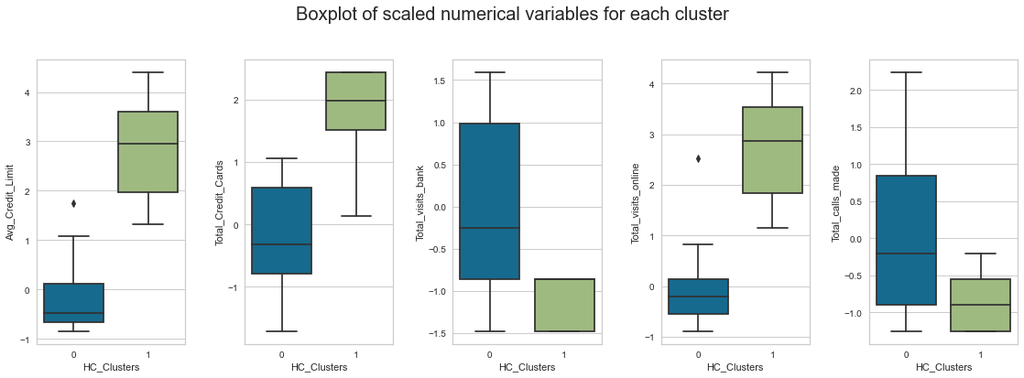

```python
fig, axes = plt.subplots(1, 5, figsize=(16, 6))
fig.suptitle("Boxplot of scaled numerical variables for each cluster", fontsize=20)
counter = 0
for ii in range(5):
    sns.boxplot(
        ax=axes[ii],
        y=subset_scaled_df[num_col[counter]],
        x=subset_scaled_df["HC_Clusters"],
    )
    counter = counter + 1

fig.tight_layout(pad=2.0)
```

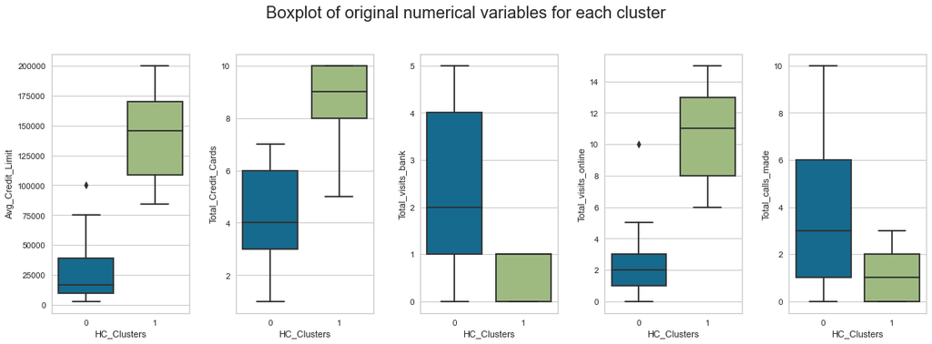

```python
fig, axes = plt.subplots(1, 5, figsize=(16, 6))
fig.suptitle("Boxplot of original numerical variables for each cluster", fontsize=20)
counter = 0
for ii in range(5):
    sns.boxplot(ax=axes[ii], y=df[num_col[counter]], x=df["HC_Clusters"])
    counter = counter + 1

fig.tight_layout(pad=2.0)
```

## Insights

### Cluster 1

- Customers in this cluster have medium to high avg_credit_limit. This cluster also has higher total_credit_cards, with a median of 9 total_credit_cards. The total_visits_bank is very low from 0 to 1 and the total_calls_made is also very low, however the total_vists_online is very high for this cluster with a median of 11.

### K-means clustering vs Hierarchical clustering

- Both clustering methods were quick and did not take much time to run.
- K means clustering and Hierarchical clustering provided different clusters. The best silhouette score for K means was 0.51 with 3 clusters using Euclidean distance. The best silhoutte score for Hierarchical clustering was 0.57 using Euclidean distance and average linkage using 2 clusters.
- K means clustering provided more distinct groups. Cluster 1 had very low credit limit, then cluster 0 had low to medium credit_limit. And cluster 2 had customers with very high credit limit. Also Cluster 1 had the lowest total_credit_cards and then cluster 0 had medium total_credit_cards and cluster 2 had the highest number of total_credit_cards. Cluster 2 had the lowest number of vists to the bank and the highest online visits, Cluster 0 had the highest vists to the bank and the least online visits. Cluster 2 also had the lowest total_calls_made and Cluster 1 had the highest number of total_calls_made.
- Hierarchical clustering provided just 2 groups. Cluster 0 had customers with low to medium avg_credit_limit and total_credit_cards. Cluster 1 had medium to high avg_credit_limit and total_credit_cards. For cluster 0 the total_visits_bank is medium to high and the total_vists_online is low. For cluster 1 the total_visits_bank and total_calls_made is very low however, the total_vists_online is very high.

#### Since Kmeans clustering gave more distinct clusters, the business should go ahead with Kmeans clustering using 3 clusters

## Business Recommendations

Cluster 0 has low to medium credit limit with the median credit limit of a little over 25,000. Also this cluster has medium range for total_credit_cards. The business can target these customers to see if they would be interested in more cards.

Cluster 0 also had very high visits to the bank but lower online visits and lower calls made. The business can see how to improve their online and phone service for this cluster.

Customers in cluster 1 have very low avg_credit limit, the business can see if they can target these customers and maybe increase their credit limits. Also they can be targeted for more credit card sales, since they have very few credit cards.

Cluster 1 also had lower vists to the bank and online, however they a high number of calls made. The business should look into their phone service and see how it can be improved for this cluster

Cluster 2 had the highest avg_credit_limit and total_cards, these are probably the elite customers. The business should ensure that customer satisfaction rate is high.

Cluster 2 had the lowest visits to the bank and low total_calls_made but very high online activity. The business should look into this group and improve online experience for them. Also look at reasons why this group has higher online activity, maybe these are customers with higher incomes so they can afford a computer/laptop/internet access.